# IXORA-S Clinical Trial

A Bayesian Analysis of Treatments for Plaque Psoriasis

## Introduction

My motivation is to compare two biologic medications, Ixekizumab Q2W and Ustekinumab, for the treatment of plaque psoriasis using a Bayesian analysis. The data was collected by the IXORA-S clinical trial, sponsored by Eli Lilly and Company. It can be found in the `multinma` package in R. The dataset is `plaque_psoriasis_ipd` filtered for `studyc == "IXORA-S"`. The sample size is 260 patients, randomized to Ixekizumab (n = 118) and Ustekinumab (n = 142). The efficacy of each treatment was determined by improvement in a patient’s Psoriasis Area and Severity Index (PASI), a measurement of the extent and severity of a patient’s psoriasis plaques. The variables under study are:

- `pasi90`: binary PASI 90 outcome
- `trtc`: assigned treatment
- `age`: age of patient in years

## Analysis Ignoring `trtc` and `age`

The parameter of interest, denoted $\theta$, is the probability of achieving a PASI score of 90 or greater after one year of treatment. The outcome variable, $Y$ = `pasi90`, is an aggregation of independent Bernoulli trials, therefore can be modeled with a binomial distribution. The likelihood is: $f(Y|\theta) \sim Binomial(n, \theta)$. I use an uninformative prior beta distribution to model $\theta$: $\pi(\theta) \sim Beta(1,1)$. This prior assigns equal probability to all possible values of $\theta \in [0,1]$, yet Table 1 demonstrates little sensitivity to prior assumptions. The resulting posterior distribution is:

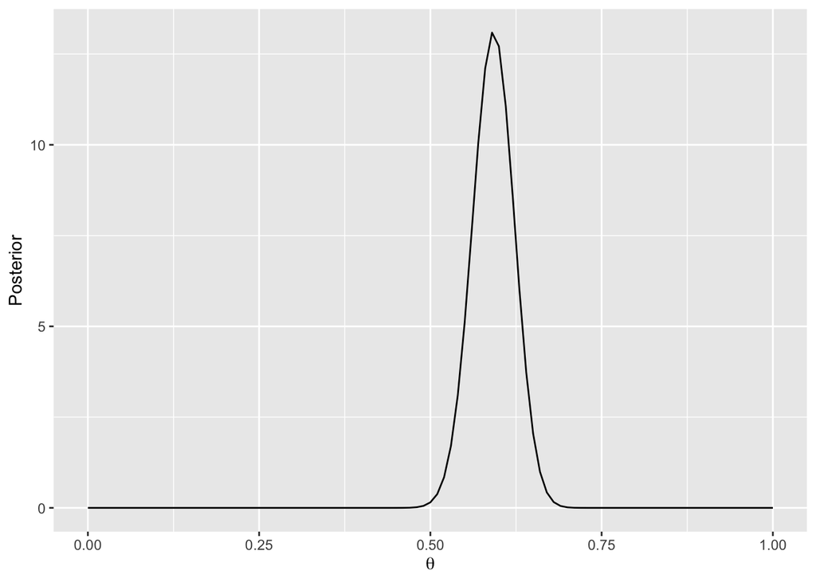

Table 1: Sensitivity Analysis

| Prior | Posterior Mean | Posterior SD |
| --- | --- | --- |
| Beta(1,1) | 0.5916 | 0.0303 |
| Beta(1,4) | 0.5849 | 0.0302 |
| Beta(3,3) | 0.5902 | 0.0301 |
| Beta(4,1) | 0.5962 | 0.0301 |

## The Binomial Likelihood

The binomial likelihood is appropriate here because the data consists of a fixed number of independent trials with two possible outcomes. The domain of the response (subset by treatment) is all integers for $Y_i \in [0, n_i]$, where $n_i$ is the number of patients assigned to each treatment and $Y_i$ is the number of successes. I estimate Pr(success) = $\hat{\theta}_i$ using the MLE.

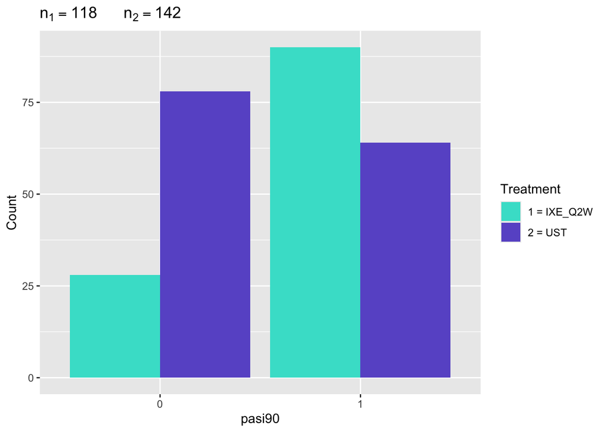

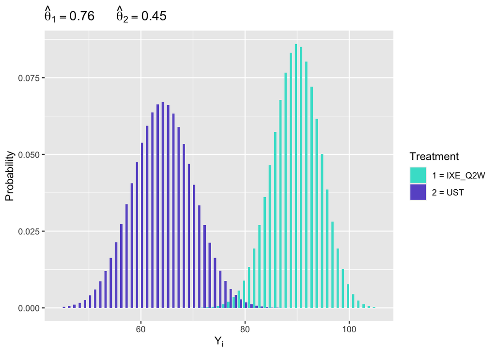

## Analysis by `trtc`

To conduct a Bayesian analysis by treatment group (1 = Ixekizumab Q2W and 2 = Ustekinumab), I employ the same likelihood and prior from section 2. The resulting posterior distributions are: $P(\theta_1|Y_1) \propto Beta(Y_1+1, n_1-Y_1+1)$ and $P(\theta_2|Y_2) \propto Beta(Y_2+1, n_2-Y_2+1)$.

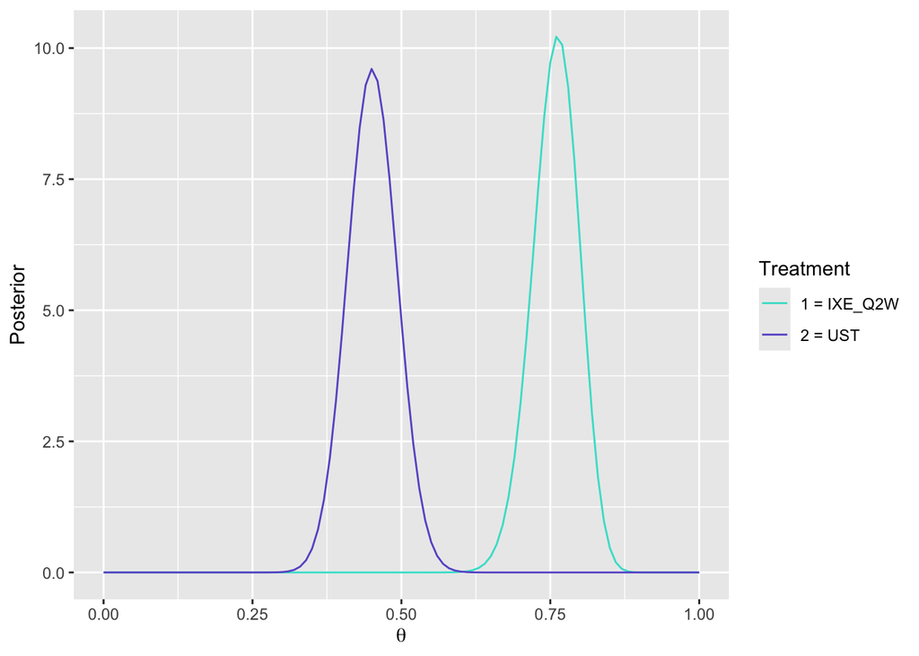

## Analysis by `trtc` and `age`

For patients under the age of 50, the probability that the rate of success for Ixekizumab Q2W is higher than the rate of success for Ustekinumab is 1. At confidence level 0.95, there is enough evidence to conclude Ixekizumab Q2W is the more effective treatment.

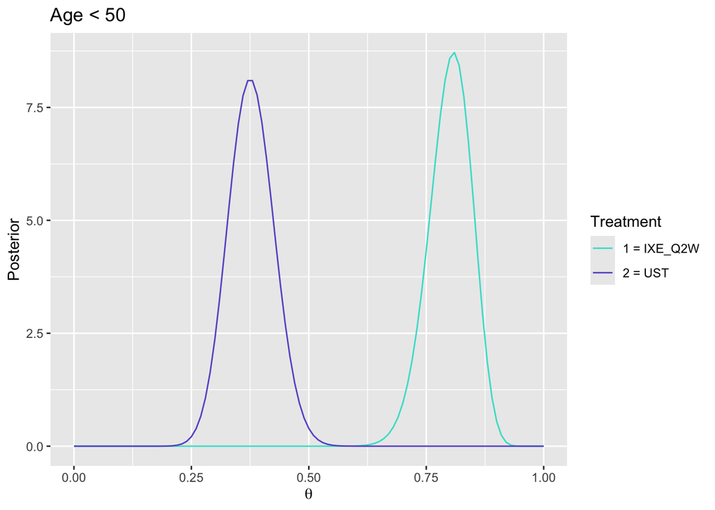

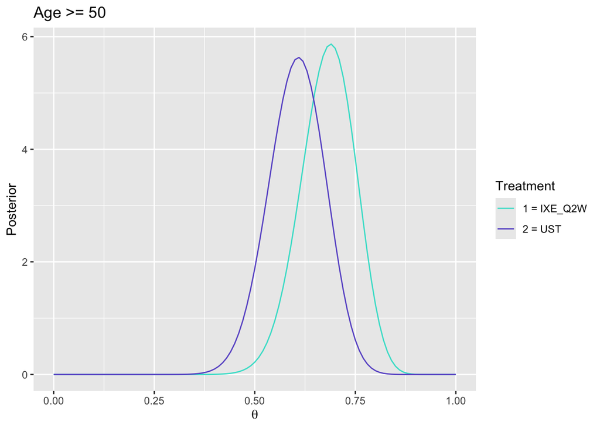

## Appendix: R Code

```r
## set chunk options
knitr::opts_chunk$set(echo = FALSE, warning = FALSE, message = FALSE, fig.align = "center")
options(scipen = 999)
## load libraries
library(multinma)
library(tidyverse)
library(knitr)
library(latex2exp)
## load data and select variables
psoriasis <- plaque_psoriasis_ipd |>
  filter(studyc == "IXORA-S") |>
  select(studyc, trtc_long, trtc, pasi90, age) |>
  mutate(pasi90 = factor(pasi90))
## get sample size by treatment
trt_counts <- psoriasis |>
  group_by(trtc_long) |>
  summarise(Count = n()) |>
  rename(Treatment = trtc_long)
trt_counts
## summarize outcomes
psoriasis |>
  group_by(trtc_long, pasi90) |>
  summarise(count = n())
## set parameters
Y <- sum(psoriasis$pasi90 == 1)
n <- nrow(psoriasis)
a <- 1
b <- 1
x <- seq(0, 1, by = 0.01)
## posterior function
post <- function(x){dbeta(x, Y + a, n - Y + b)}
## base plot
g <- ggplot(data.frame(x), aes(x = x)) +
  xlab(expression(theta)) +
  ylab("Posterior")
## plot the posterior
g + stat_function(fun = post)
## sensitivity analysis
pri <- c("Beta(1,1)", "Beta(1,4)", "Beta(3,3)", "Beta(4,1)")
A <- c(Y + 1, Y + 1, Y + 3, Y + 4)
B <- c(n - Y + 1, n - Y + 4, n - Y + 3, n - Y + 1)
mean <- c()
sd <- c()
## calculate posterior means and SDs
for(i in 1:4){
  mean[i] <- A[i]/(A[i] + B[i])
  sd[i] <- sqrt((A[i]*B[i])/((A[i]+B[i])^2*(A[i] + B[i] + 1)))
}
## summary table
kable(tibble("Prior" = pri,
             "Posterior Mean" = round(mean, 4),
             "Posterior SD" = round(sd, 4)),
      caption = "Table 1: Sensitivity Analysis")
## plot distribution of pasi90 by trtc
ggplot(psoriasis, aes(x = pasi90)) +
  geom_bar(aes(fill = trtc), position = "dodge") +
  labs(fill = "Treatment") +
  scale_fill_manual(values = c("turquoise", "slateblue"),
                    labels = c("1 = IXE_Q2W", "2 = UST")) +
  ylab("Count") +
  labs(title = TeX("$n_{1} = 118$      $n_{2} = 142$"))
## values for plotting
yvals <- c(seq(45, 105, by = 1), seq(45, 105, by = 1))
## fit binomial likelihood to each treatment group
density <- c(dbinom(45:105, 118, 90/(90+28)), dbinom(45:105, 142, 64/(78+64)))
trt <- c(rep("IXE_Q2W", 61), rep("UST", 61))
pmf <- data.frame(yvals, density, trt)
## plot binomial approximations
ggplot(pmf, aes(x = yvals)) +
  geom_col(aes(y = density, fill = trt), position = "dodge") +
  scale_fill_manual(values = c("turquoise", "slateblue"),
                    labels = c("1 = IXE_Q2W", "2 = UST")) +
  labs(fill = "Treatment") +
  xlab(TeX("$\\Y_i$")) +
  ylab("Probability") +
  labs(title = TeX("$\\hat{\\theta}_{1} = 0.76$      $\\hat{\\theta}_{2} = 0.45$"))
## count number of successes for each treatment
Y1 <- sum(psoriasis$pasi90 == 1 & psoriasis$trtc == "IXE_Q2W")
Y2 <- sum(psoriasis$pasi90 == 1 & psoriasis$trtc == "UST")
## sample sizes
n1 <- sum(psoriasis$trtc == "IXE_Q2W")
n2 <- sum(psoriasis$trtc == "UST")
## calculate posterior distributions
post1 <- function(x){dbeta(x, Y1 + a, n1 - Y1 + b)}
post2 <- function(x){dbeta(x, Y2 + a, n2 - Y2 + b)}
## plot posterior distributions
g  +
  stat_function(fun = post1, aes(color = "IXE_Q2W")) +
  stat_function(fun = post2, aes(color = "UST")) +
  scale_color_manual(values = c("turquoise", "slateblue"),
                     labels = c("1 = IXE_Q2W", "2 = UST")) +
  labs(color = "Treatment")
## Monte Carlo simulation
set.seed(20)
## set number of samples
N <- 1000000
## draw from posteriors
t1 <- rbeta(N, Y1 + a, n1 - Y1 + b)
t2 <- rbeta(N, Y2 + a, n2 - Y2 + b)
## summarize results
Outcome = c("$\\theta_1 < \\theta_2$", "$\\theta_1 > \\theta_2$")
Count = c(sum(t1 < t2), sum(t1 > t2))
kable(tibble(Outcome, Count), escape = FALSE, format = "latex")
## count successes by treatment and subgroup for IXE
Y3 <- sum(psoriasis$pasi90 == 1 & psoriasis$trtc == "IXE_Q2W" & psoriasis$age < 50)
Y4 <- sum(psoriasis$pasi90 == 1 & psoriasis$trtc == "IXE_Q2W" & psoriasis$age >= 50)
## sample sizes
n3 <- sum(psoriasis$trtc == "IXE_Q2W" & psoriasis$age < 50)
n4 <- sum(psoriasis$trtc == "IXE_Q2W" & psoriasis$age >= 50)
## count successes by treatment and subgroup for UST
Y5 <- sum(psoriasis$pasi90 == 1 & psoriasis$trtc == "UST" & psoriasis$age < 50)
Y6 <- sum(psoriasis$pasi90 == 1 & psoriasis$trtc == "UST" & psoriasis$age >= 50)
## sample sizes
n5 <- sum(psoriasis$trtc == "UST" & psoriasis$age < 50)
n6 <- sum(psoriasis$trtc == "UST" & psoriasis$age >= 50)
## define posterior distributions for each subgroup by treatment
post3 <- function(x){dbeta(x, Y3 + a, n3 - Y3 + b)}
post4 <- function(x){dbeta(x, Y4 + a, n4 - Y4 + b)}
post5 <- function(x){dbeta(x, Y5 + a, n5 - Y5 + b)}
post6 <- function(x){dbeta(x, Y6 + a, n6 - Y6 + b)}
## plot posteriors for under 50 subgroup
g  +
  stat_function(fun = post3, aes(color = "IXE_Q2W")) +
  stat_function(fun = post5, aes(color = "UST")) +
  scale_color_manual(values = c("turquoise", "slateblue"),
                     labels = c("1 = IXE_Q2W", "2 = UST")) +
  labs(color = "Treatment", title = "Age < 50")
## plot posteriors for 50 and older subgroup
g  +
  stat_function(fun = post4, aes(color = "IXE_Q2W")) +
  stat_function(fun = post6, aes(color = "UST")) +
  scale_color_manual(values = c("turquoise", "slateblue"),
                     labels = c("1 = IXE_Q2W", "2 = UST")) +
  labs(color = "Treatment", title = "Age >= 50")
## Monte Carlo simulation
set.seed(20)
## draw from posteriors
t3 <- rbeta(N, Y3 + a, n3 - Y3 + b)
t4 <- rbeta(N, Y4 + a, n4 - Y4 + b)
t5 <- rbeta(N, Y5 + a, n5 - Y5 + b)
t6 <- rbeta(N, Y6 + a, n6 - Y6 + b)
## summarize results
Age <- c(rep("under 50", 2), rep("50 and older", 2))
Outcome = c("$\\theta_1 < \\theta_2$", "$\\theta_1 > \\theta_2$",
            "$\\theta_1 < \\theta_2$", "$\\theta_1 > \\theta_2$")
Count = c(sum(t3 < t5), sum(t3 > t5), sum(t4 < t6), sum(t4 > t6))
kable(tibble(Age, Outcome, Count), escape = FALSE, format = "latex")
## calculate hypothesis test results: pr(theta1 > theta2)
Age <- c("under 50", "50 and older")
pr <- c(sum(t3 > t5)/N, sum(t4 > t6)/N)
kable(tibble(Age, "$Pr(\\theta_1 > \\theta_2)$" = round(pr, 3)),
      escape = FALSE, format = "latex")
```